# R Notebook

## 1.1 File metadata

Template author: Morgan Carr-Markell  
Template last modified on: March 28, 2023  
Notebook modified by: Katie Wang  
Notebook last modified on: April 3, 2023

## 1.2 Data sources

Species occurrence data:

GBIF.org (29 March 2023) GBIF Occurrence Download https://doi.org/10.15468/dl.7qgrxe

Environmental data:

Fick, S.E. and R.J. Hijmans, 2017. WorldClim 2: new 1km spatial resolution climate surfaces for global land areas. International Journal of Climatology 37 (12): 4302-4315.

## 1.3 Code sources

Much of the code is inspired by or directly adapted from these four sources:

The ENMeval 2.0 Vignette By Jamie M. Kass, Robert Muscarella, Gonzalo E. Pinilla-Buitrago, and Peter J. Galante Date: January 9th, 2023 https://jamiemkass.github.io/ENMeval/articles/ENMeval-2.0-vignette.html

Preparing Data for MaxEnt Species Distribution Modeling Using R By Dale Watt Date: October 9th, 2018 https://www.azavea.com/blog/2018/10/09/preparing-data-for-maxent-species-distribution-modeling-using-r/

Tutorials from The Banta Lab By Josh Banta https://sites.google.com/site/thebantalab/tutorials?authuser=0

Code shared by Prof. Stephen Adolph and his students Daniel Furman and Sarah Halvorsen from their desert night lizard species distribution modeling project https://magazine.hmc.edu/summer-2019/researching-for-an-answer/

## 1.4 Libraries

```r
library(tidyverse)
library(raster)
library(terra)
library(geodata)
library(sf)
library(rnaturalearth)
library(rnaturalearthdata)
```

## 2 Occurrence data

### 2.1 Downloading data

1. For the in_class assignment, you will be using data I already downloaded from GBIF, but for the independent assignment, you will be downloading your own data. Therefore, I would like you to look at these [directions](https://drive.google.com/file/d/1uphy1my20d--CEgnYR8xaMrc1U8EJLDE/view?usp=share_link) and see if you have any questions for me about them (you can also go ahead and download data for your species of interest if you want).

OK, now let’s read the data file I downloaded from GBIF with records of the brown-throated three-toed sloth, [Bradypus variegatus](https://en.wikipedia.org/wiki/Brown-throated_sloth).

```r
occurrences_df <- read.csv("BV_data/Bradypus_variegatus_0128065-230224095556074.csv",
                sep= "\t"  # tab-delimited file
                )

# I forgot to filter this when downloading the data
occurrences_df <- occurrences_df %>%
  filter(year >= 1950) %>%
  filter(!is.na(decimalLongitude) & !is.na(decimalLongitude))
```

### 2.2 Inspecting and filtering data

Now we can map these data and see whether we want to filter out any outliers.

You’ll probably find it helpful to refer to hw4 for this part

2. Save an sf object with multipolygons for all the countries in the world using the ne_countries() function in the rnaturalearth package (“medium” is probably a good size and returnclass should be “sf”):

```r
worldMap <- ne_countries(scale = "medium", type = "countries", returnclass = "sf")
```

3. Use the st_as_sf() function to make an sf object from the occurrences_df data frame we just created above. Use 4326 as the coordinate reference system (crs).

```r
sloth_sf <- st_as_sf(occurrences_df,
                     coords = c("decimalLongitude", "decimalLatitude"),
                     crs = 4326)
```

4. Now map the sf points you just created on top of the country boundaries using ggplot and geom_sf():

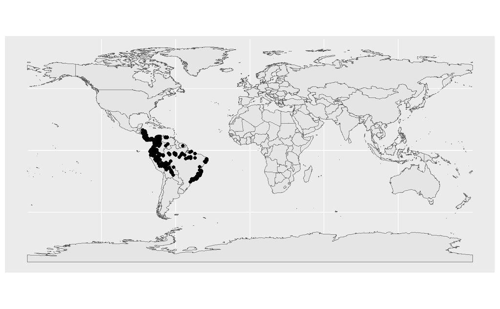

```r
ggplot() +
  geom_sf(data = worldMap) +
  geom_sf(data = sloth_sf)
```

5. Are there any outlier coordinates that we should clearly remove?  
   As far as I can see, there aren’t any apparent outliers.

Apparently, the populations east of the Amazon River are known to have different habitat preferences/needs (according to the online tutorial) so we’re going to exclude them:

```r
occurrences_df <- occurrences_df %>%
  filter(decimalLatitude > -20 & decimalLongitude < -45)
```

We could look at other aspects of the data, but it’s hard to judge other features of the records without doing some research so instead we will assume they are reasonably accurate, and use the dplyr::select function to restrict the columns to decimalLongitude and decimalLatitude:

```r
occurrences_df <- occurrences_df %>%
  dplyr::select(decimalLongitude, decimalLatitude)
```

### 2.3 Saving spatial extent

We’re going to need to crop the environmental raster layers to extend only a certain distance around the occurrence points. The easiest way to do this is to:

- remake an sf object from the occurrences data frame using the st_as_sf function
- next transform this to an equal-area projection
- then use st_buffer to extend out some reasonable distance
- then convert back to a crs with latitude and longitude coordinates
- and finally use st_bbox to get the minimum and maximum latitude and longitude values defining a bounding box around that buffer

Let’s use some advice/code from the [vignette](https://jamiemkass.github.io/ENMeval/articles/ENMeval-2.0-vignette.html) on the ENMeval package:

```r
# First, we make the occurrences points into an sf object
occurrence_sf <- st_as_sf(occurrences_df,
                          coords = c("decimalLongitude", "decimalLatitude"),
                          crs = 4326)

# Now, we project our point data to an equal-area projection, which converts our
# degrees to meters, which is ideal for buffering (the next step).
# We use the typical Eckert IV projection.
eckertIV <- "+proj=eck4 +lon_0=0 +x_0=0 +y_0=0 +datum=WGS84 +units=m +no_defs"

# Buffer all occurrences by 500 km, union the polygons together
# (for visualization), and convert back to a form that the raster package
# can use. Finally, we reproject the buffers back to WGS84 (lat/lon).
# We choose 500 km here to avoid sampling the Caribbean islands.
occurrences_buffer <- occurrence_sf %>%
  st_transform(crs = eckertIV) %>%
  st_buffer(dist = 500000) %>%  # unit here is meters
  st_union() %>%
  st_sf() %>%
  st_transform(crs = 4326)

occurrence_bounds <- occurrences_buffer %>%
  st_bbox()
```

## 3 Environmental data

Next we need to download and process any environmental layers we think might help us predict species presence.

### 3.1 Downloading data

If you are working with terrestrial species, an easy way to download data is to use the geodata package’s worldclim_global() function to download [bioclimatic variable](https://www.worldclim.org/data/bioclim.html) layers. By default, these will be 50-year averages (1950-2000). Let’s do that now:

```r
worldclim_global(
        var = "bio",  # bioclimatic variables
        download = TRUE,  # we want to save the files
        path = "BV_data",  # folder to save files to
        res = 10)  # resolution in arc minutes
```

```
class       : SpatRaster
dimensions  : 1080, 2160, 19  (nrow, ncol, nlyr)
resolution  : 0.1666667, 0.1666667  (x, y)
extent      : -180, 180, -90, 90  (xmin, xmax, ymin, ymax)
coord. ref. : lon/lat WGS 84 (EPSG:4326)
sources     : wc2.1_10m_bio_1.tif
              wc2.1_10m_bio_2.tif
              wc2.1_10m_bio_3.tif
              ... and 16 more source(s)
names       : wc2.1~bio_1, wc2.1~bio_2, wc2.1~bio_3, wc2.1~bio_4, wc2.1~bio_5, wc2.1~bio_6, ...
min values  :   -54.72435,     1.00000,    9.131122,       0.000,   -29.68600,   -72.50025, ...
max values  :    30.98764,    21.14754,  100.000000,    2363.846,    48.08275,    26.30000, ...
```

Now, we probably don’t want to use all of these variables because they may not all be very relevant. In the case of this species, online tutorials suggest these 8 variables:

- bio1 = Annual Mean Temperature
- bio5 = Max Temperature of Warmest Month
- bio6 = Min Temperature of Coldest Month
- bio7 = Temperature Annual Range (BIO5-BIO6)
- bio8 = Mean Temperature of Wettest Quarter
- bio12 = Annual Precipitation
- bio16 = Precipitation of Wettest Quarter
- bio17 = Precipitation of Driest Quarter

So let’s load in just those layers:

```r
bio1 <- raster("BV_data/wc2.1_10m/wc2.1_10m_bio_1.tif")
bio5 <- raster("BV_data/wc2.1_10m/wc2.1_10m_bio_5.tif")
bio6 <- raster("BV_data/wc2.1_10m/wc2.1_10m_bio_6.tif")
bio7 <- raster("BV_data/wc2.1_10m/wc2.1_10m_bio_7.tif")
bio8 <- raster("BV_data/wc2.1_10m/wc2.1_10m_bio_8.tif")
bio12 <- raster("BV_data/wc2.1_10m/wc2.1_10m_bio_12.tif")
bio16 <- raster("BV_data/wc2.1_10m/wc2.1_10m_bio_16.tif")
bio17 <- raster("BV_data/wc2.1_10m/wc2.1_10m_bio_17.tif")
```

If we wanted to get future climate projection data, we could use a different function from the geodata package, called cmip6_world() like this:

```r
cmip6_world(model = "CNRM-CM6-1", # climate model abbreviation
            ssp = "585", # Shared Socio-economic Pathway code
            time = "2041-2060", # future time period
            var = "bioc", # bioclimatic variables
            res = 10, # 10 arc minute resolution
            path = "BV_data" # where to save files
            )
```

```
class       : SpatRaster
dimensions  : 1080, 2160, 19  (nrow, ncol, nlyr)
resolution  : 0.1666667, 0.1666667  (x, y)
extent      : -180, 180, -90, 90  (xmin, xmax, ymin, ymax)
coord. ref. : lon/lat WGS 84 (EPSG:4326)
source      : wc2.1_10m_bioc_CNRM-CM6-1_ssp585_2041-2060.tif
names       : bio01, bio02, bio03,  bio04, bio05, bio06, ...
min values  : -52.1,  -0.2,  -2.2,   12.3, -27.6, -70.4, ...
max values  :  33.5,  21.6,  94.8, 2303.5,  51.9,  26.2, ...
```

In contrast to the worldclim() function, this saves only one GEOtiff file for all the 19 bioclimatic variables as opposed to 19.

You will likely need to download some data directly from websites. The files they provide may be .tif, .bil, .asc, .nc, or other formats. Generally speaking, you can use the functions raster(), for a single variable/layer per file, or brick(), for multiple variables/layers per file, to read in any of those formats. However, you may run into errors. If so, let me know, and we can work on it together.

### 3.2 Inspecting data

So we have 8 bioclimatic raster layers. These we can be certain have the same extent, resolution, and crs because we downloaded them all from the same database and asked for the same extent and resolution. However, if you use layers from different sources, that will likely not be the case. For our analysis, they need to be the same so that we can analyze by grid squares (each one having its own set of environmental values).

6. Try plotting a few of them using the plot() function from base R (much faster than ggplot for raster layers):

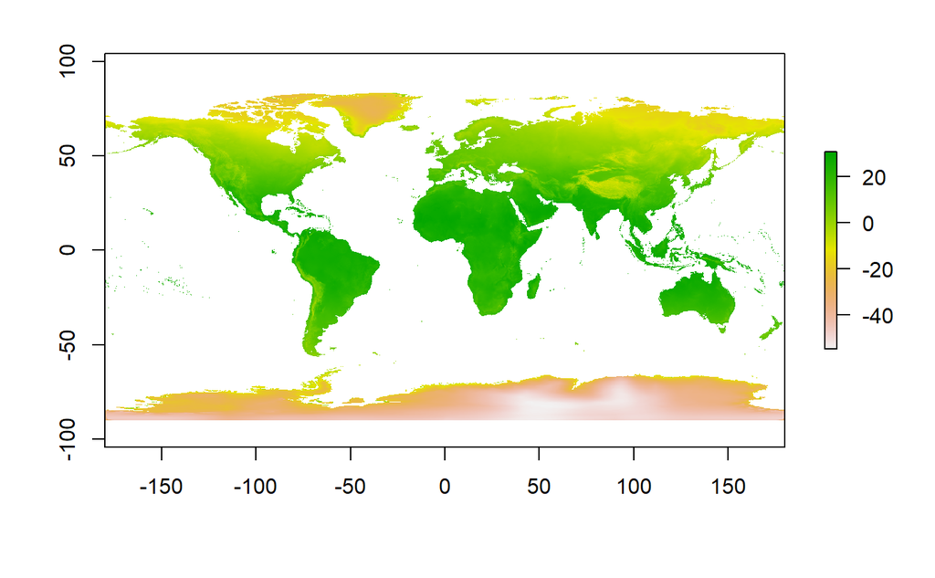

```r
plot(bio1)
```

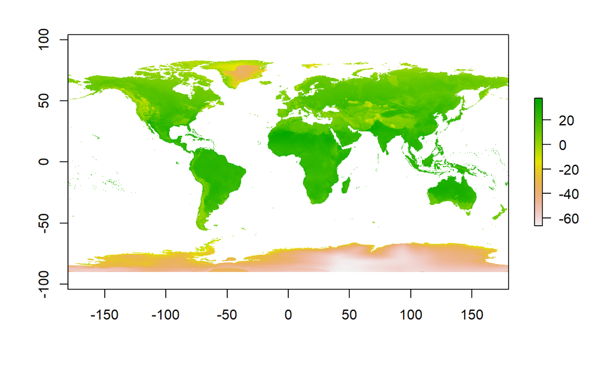

```r
plot(bio8)
```

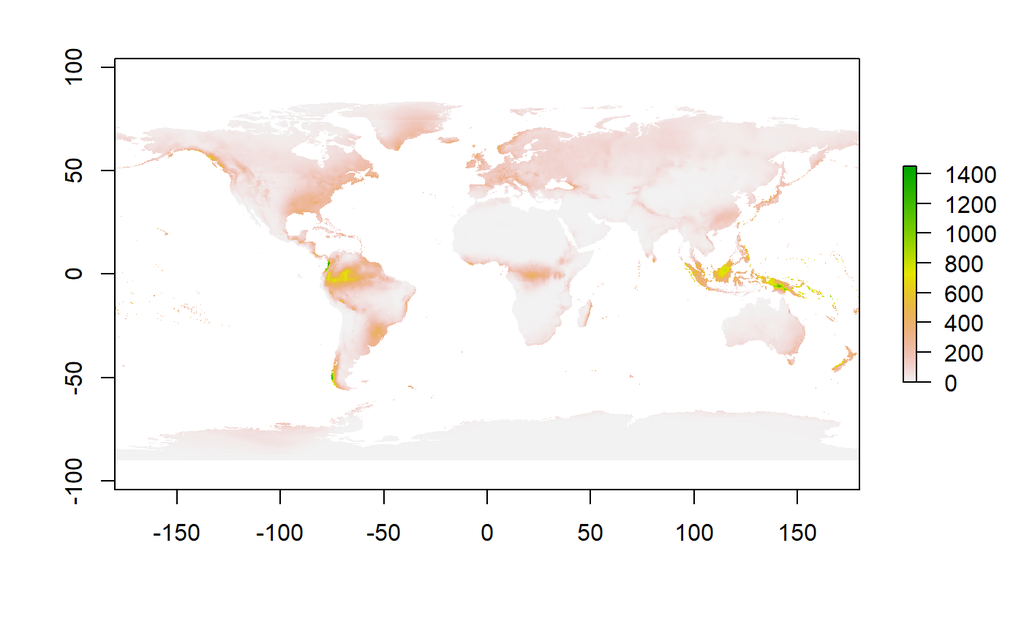

```r
plot(bio17)
```

### 3.3 Standardardizing crs, resolution, and spatial extent

So let’s practice looking at and changing these three features of our raster layers. We’ve seen how to do this in hw5 when we worked with NEON raster data so it may be helpful to refer to that assignment.

#### 3.3.1 Coordinate reference system

```r
crs(bio1)
```

```
Coordinate Reference System:
Deprecated Proj.4 representation: +proj=longlat +datum=WGS84 +no_defs
WKT2 2019 representation:
GEOGCRS["unknown",
    DATUM["World Geodetic System 1984",
        ELLIPSOID["WGS 84",6378137,298.257223563,
            LENGTHUNIT["metre",1]],
        ID["EPSG",6326]],
    PRIMEM["Greenwich",0,
        ANGLEUNIT["degree",0.0174532925199433],
        ID["EPSG",8901]],
    CS[ellipsoidal,2],
        AXIS["longitude",east,
            ORDER[1],
            ANGLEUNIT["degree",0.0174532925199433,
                ID["EPSG",9122]]],
        AXIS["latitude",north,
            ORDER[2],
            ANGLEUNIT["degree",0.0174532925199433,
                ID["EPSG",9122]]]]
```

This is WGS84, or ESPG code 4326. Let’s try changing it and bio5 to NAD83 or ESPG code 4269:

```r
bio1_nad83 <- projectRaster(bio1, crs = 4269)
bio5_nad83 <- projectRaster(bio5, crs = 4269)
```

#### 3.3.2 Resolution

Now let’s look at their resolutions (how large each grid square is):

```r
res(bio1_nad83)
```

```
[1] 0.167 0.167
```

```r
res(bio5_nad83)
```

```
[1] 0.167 0.167
```

If we wanted, we could change the resolution as well. Let’s create a situation in which the two layers have different resolutions:

```r
bio1_nad83 <- bio1_nad83 %>%
  aggregate(fact = 4, # factor to aggregate grid squares by
            fun = mean) # function to use when aggregating values
```

7. What are the resolutions of bio1_nad83 and bio5_nad83 now?

```r
res(bio1_nad83) # resolution was changed in the code block above
```

```
[1] 0.668 0.668
```

```r
res(bio5_nad83) # resolution was not changed; addressed below
```

```
[1] 0.167 0.167
```

We can fix this situation by using the resample function, which lets us match the resolution of one raster layer to another:

```r
bio5_nad83 <- bio5_nad83 %>%
  resample(bio1_nad83)
```

Let’s check that we fixed the problem:

```r
res(bio1_nad83)
```

```
[1] 0.668 0.668
```

```r
res(bio5_nad83)
```

```
[1] 0.668 0.668
```

Yay!

#### 3.3.3 Extent

Finally, we have to standardize the extents of all of the layers if we want to group them into a raster stack. If you have layers that all cover the whole globe, you just crop the layers to the extent of your occurrence_bounds. However, if you have one smaller layer, it’s possible that you’ll want to extend it to match the larger layers. This will fill in NoData values for all of the extended space in that layer. Let’s try it out:

```r
ext(bio1_nad83)
```

```
SpatExtent : -180, 180.052, -90.36, 90 (xmin, xmax, ymin, ymax)
```

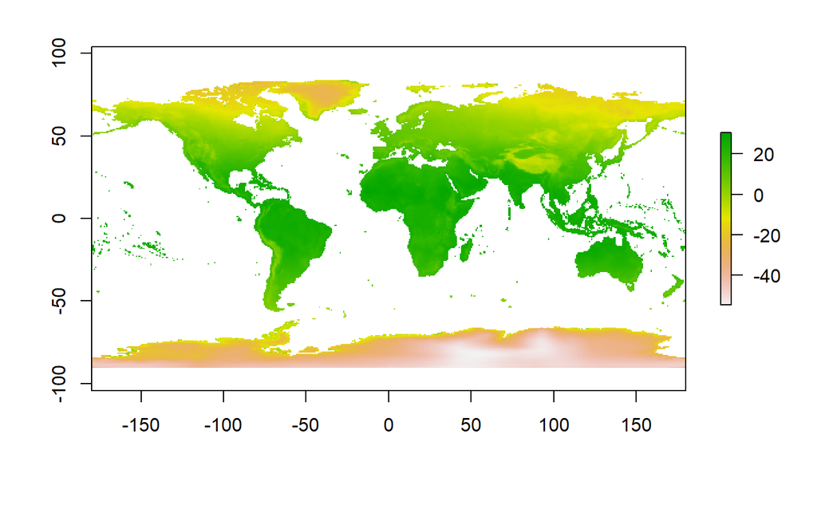

```r
plot(bio1_nad83)
```

```r
bio1_nad83 <- bio1_nad83 %>%
  crop(occurrence_bounds) %>%  # creating a smaller layer
  extend(extent(bio5_nad83))  # filling in NAs to match the larger layer

plot(bio1_nad83)
```

[output not shown]

8. Use the extent() function to check that the extents are now the same between bio1_nad83 and bio5_nad83:

```r
ext(bio1_nad83)
```

```
SpatExtent : -180, 180.052, -90.36, 90 (xmin, xmax, ymin, ymax)
```

```r
ext(bio5_nad83)
```

```
SpatExtent : -180, 180.052, -90.36, 90 (xmin, xmax, ymin, ymax)
```

9. Now crop all eight of the bio1 through bio17 raster layers that we created above to the occurrence_bounds extent:

```r
# We actually want to do this on the WGS84 ones, not the dummy _nad83 layers
# which were just to illustrate what we would do if our data came from different sources
# our raster layers: bio1, bio5, bio6, bio7, bio8, bio12, bio16, bio17

bio1 <- bio1 %>%
  crop(occurrence_bounds)

bio5 <- bio5 %>%
  crop(occurrence_bounds)

bio6 <- bio6 %>%
  crop(occurrence_bounds)

bio7 <- bio7 %>%
  crop(occurrence_bounds)

bio8 <- bio8 %>%
  crop(occurrence_bounds)

bio12 <- bio12 %>%
  crop(occurrence_bounds)

bio16 <- bio16 %>%
  crop(occurrence_bounds)

bio17 <- bio17 %>%
  crop(occurrence_bounds)

# now check that all the extents match
ext(bio1)
```

```
SpatExtent : -92.3333333333333, -41.8333333333333, -22, 20.1666666666667 (xmin, xmax, ymin, ymax)
```

```r
ext(bio5)
```

```
SpatExtent : -92.3333333333333, -41.8333333333333, -22, 20.1666666666667 (xmin, xmax, ymin, ymax)
```

```r
ext(bio6)
```

```
SpatExtent : -92.3333333333333, -41.8333333333333, -22, 20.1666666666667 (xmin, xmax, ymin, ymax)
```

```r
ext(bio7)
```

```
SpatExtent : -92.3333333333333, -41.8333333333333, -22, 20.1666666666667 (xmin, xmax, ymin, ymax)
```

```r
ext(bio8)
```

```
SpatExtent : -92.3333333333333, -41.8333333333333, -22, 20.1666666666667 (xmin, xmax, ymin, ymax)
```

```r
ext(bio12)
```

```
SpatExtent : -92.3333333333333, -41.8333333333333, -22, 20.1666666666667 (xmin, xmax, ymin, ymax)
```

```r
ext(bio16)
```

```
SpatExtent : -92.3333333333333, -41.8333333333333, -22, 20.1666666666667 (xmin, xmax, ymin, ymax)
```

```r
ext(bio17)
```

```
SpatExtent : -92.3333333333333, -41.8333333333333, -22, 20.1666666666667 (xmin, xmax, ymin, ymax)
```

### 3.4 Creating a raster stack

Creating a raster stack is easy if all the layers are in the same crs, they have the same resolution, and they have the same extent. We just use the stack() function and input a list of raster layers:

```r
bio_stack <- stack(list(bio1,
                        bio5,
                        bio6,
                        bio7,
                        bio8,
                        bio12,
                        bio16,
                        bio17))
```

10. Look in the Environment pane. What are the types of bio_stack and bio1?  
    bio_stack is of the RasterStack type while bio1 is of the RasterLayer type.

### 3.5 Exporting the processed raster layers as geoTIFF files

Now we want to save our hard processing work so we’ll output this stack as GEOtiff files in a new BV_processed_data folder using the writeRaster() function:

```r
if (!dir.exists("BV_processed_data")){
  dir.create("BV_processed_data")
}

file_names <- paste0("BV_processed_data/", names(bio_stack))

writeRaster(bio_stack,
            filename = file_names,
            format = "Gtiff",  # specify output format
            bylayer = TRUE,
            overwrite = TRUE, # CAUTION: if this is true, it will overwrite an existing file
            NAflag = -9999)
```

## 4 Dealing with spatial autocorrelation

The next issue we must deal with is the fact that many of these points are likely very close to one another. They are likely to be on the same raster grid squares in fact. Let’s look at that:

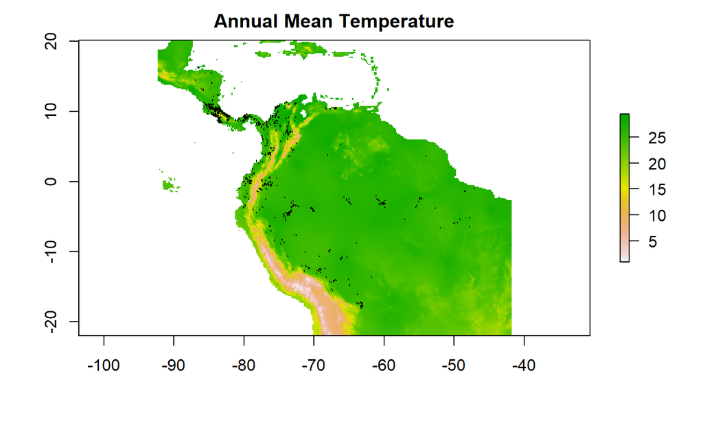

```r
plot(bio1, main = "Annual Mean Temperature")
points(occurrences_df, pch = 20, cex = 0.2)
```

So what should we do about this? There are multiple ways of dealing with this problem. We’ll use the method suggested in the ENMeval vignette:

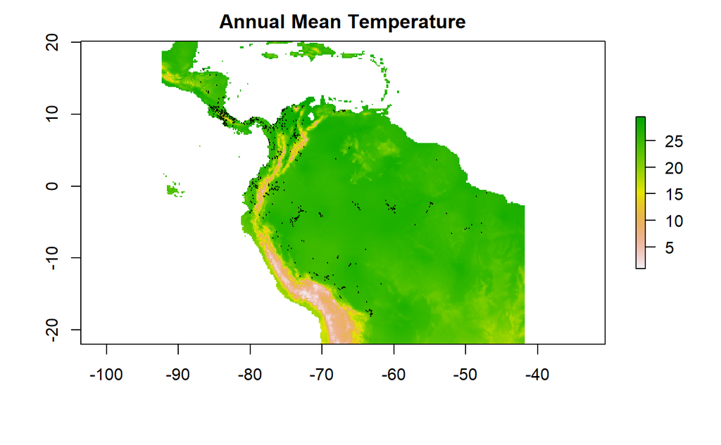

```r
# Let's now remove occurrences that are cell duplicates -- these are
# occurrences that share a grid cell in the predictor variable rasters.
# Although Maxent does this by default, keep in mind that for other algorithms you may
# or may not want to do this based on the aims of your study.
# Another way to space occurrence records a defined distance from each other to avoid
# spatial autocorrelation is with spatial thinning (Aiello-Lammens et al. 2015).
occurrence_cells <- raster::extract(bio1,
                            occurrences_df,
                            cellnumbers = TRUE)
occurrence_cellDups <- duplicated(occurrence_cells[ , 1])
occurrences_df <- occurrences_df[!occurrence_cellDups, ]

plot(bio1, main = "Annual Mean Temperature")
points(occurrences_df, pch = 20, cex = 0.2)
```

## 5 Background points

Last but not least, we need a set of locations to compare with the locations where the sloths were found (0s to compare with the 1s). Unfortunately, we usually do not have data from locations were someone actually tried hard to find the species and failed. Therefore, what we usually do instead is randomly sample locations around the points were the species occurred. The idea is to try to find locations that the species could have reached from their current locations. Of course, this will include some locations that represent suitable habitats, but we can still draw conclusions based on comparing the randomly chosen background points to known occurrence points.

### 5.1 Generating background

So how do we generate these background points?

```r
plot(bio1, main = "Annual Mean Temperature")
points(occurrences_df[ , c("decimalLongitude", "decimalLatitude")])
```

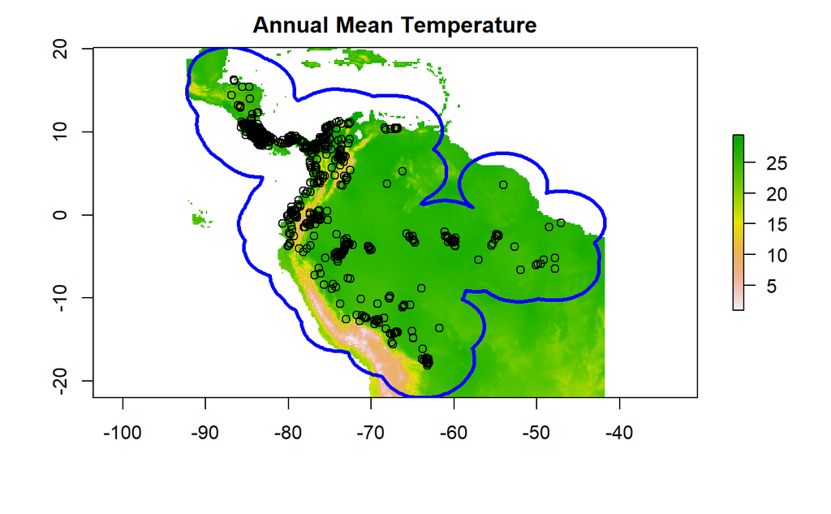

```r
# To add sf objects to a plot, use add = TRUE
plot(occurrences_buffer, border = "blue", lwd = 3, add = TRUE)
```

The buffer outlined in blue surrounds the areas that we will draw our random background points from. Let’s crop the grid cells to that buffer so we can draw from them:

```r
# Crop environmental raster to match the study extent
envs_background <- raster::crop(bio1, occurrences_buffer)

# Next, mask the raster to the shape of the buffers
envs_background  <- raster::mask(envs_background, occurrences_buffer)

# Now plot it
plot(envs_background, main = "Annual Mean Temperature")
points(occurrences_df[ , c("decimalLongitude", "decimalLatitude")])
```

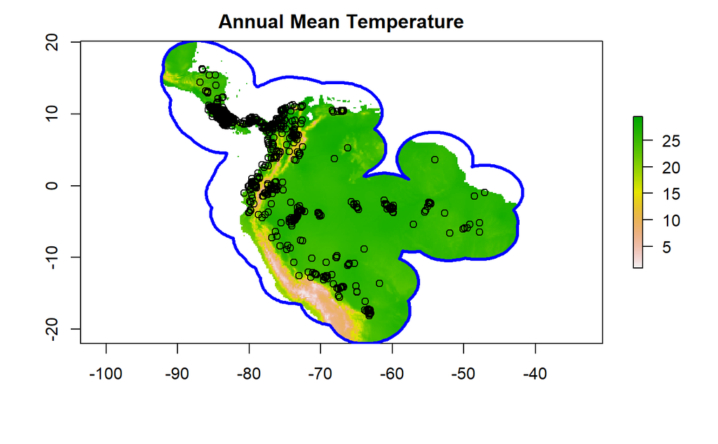

```r
plot(occurrences_buffer, border = "blue", lwd = 3, add = TRUE)
```

Now we can sample points (using 10,000 based on the vignette):

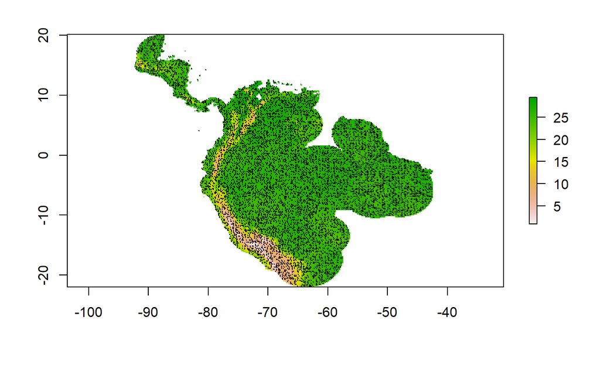

```r
# Randomly sample 10,000 background points from one background extent raster
# (only one per cell without replacement). Note: Since the raster has <10,000 pixels,
# you'll get a warning and all pixels will be used for background. We will be sampling
# from the biome variable because it is missing some grid cells, and we are trying to
# avoid getting background points with NA. If one raster in the stack has NAs where the
# other rasters have data, ENMeval internally converts these cells to NA.
background_df <- dismo::randomPoints(envs_background, n = 10000) %>% as.data.frame()
colnames(background_df) <- colnames(occurrences_df)

# Notice how we have pretty good coverage
plot(envs_background)
points(background_df, pch = 20, cex = 0.2)
```

### 5.2 Plotting occurence and background points

Let’s do a final check by plotting background points in black and thinned occurrence points in red:

```r
plot(bio1, main = "Annual Mean Temperature")
points(background_df, pch = 20, cex = 0.2)  # default color is black
```

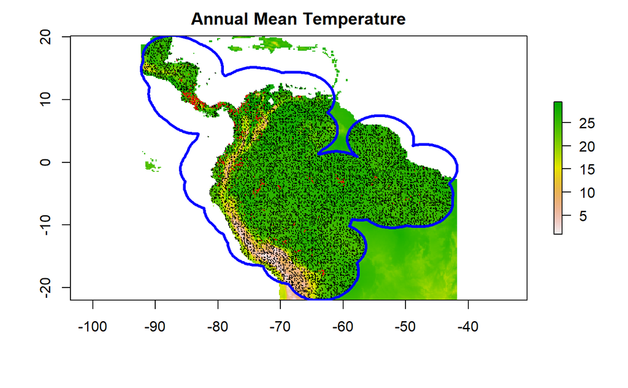

```r
points(occurrences_df, col = "red", pch = 20, cex = 0.2)
# To add sf objects to a plot, use add = TRUE
plot(occurrences_buffer, border = "blue", lwd = 3, add = TRUE)
```

### 5.3 Writing out points

Now we need to save our processed occurrence and background points.

10. Use the write.csv() function to save the occurrence_df and background_df in the BV_processed_data folder. Remember to use row.names = FALSE:

```r
write.csv(occurrences_df,
          file = "BV_processed_data/occurrences.csv",
          row.names = FALSE)

write.csv(background_df,
          file = "BV_processed_data/background.csv",
          row.names = FALSE)
```

Congrats! Now you are ready to work on processing the data for your species of interest.